# Data Analyses Script (Supplemental Materials) for the project, Association Between CAIDE Risk Score and Episodic Memory in Middle-Aged Females: The Impact of Natural Menopause

Julia Kearley, McGill University

2025-04-17

> **Note:** This script is for the **Supplemental Materials Analyses** to the manuscript:

> *Kearley, J. et al. (2025). Association Between CAIDE Risk Score and Episodic Memory in Middle-Aged Females: The Impact of Natural Menopause.*

## 1 Reproducibility Requirements

- **R version:** 4.3 or later
- **Required R packages:** (see loaded libraries below)
- **Data:** Saved R objects from `Kearley_bhamm_memory_rf_script2.rmd`

## 2 Analysis Overview

### 2.1 Sup1 (Figure S2): Modified CAIDE Score (Excluding Age Points)

- Summary statistics (overall and by group)
- Mann-Whitney U test
- Histogram by menopause status

### 2.2 Sup2 (Table S1): LRT Tests (CS retrieval ~ Task × CAIDE)

- Premenopausal and postmenopausal groups

### 2.3 Sup3 (Table S2): LRT Tests (Novelty detection ~ Task × CAIDE)

- Premenopausal and postmenopausal groups

### 2.4 Sup4 (Table S3): Between-Group Mixed-Effect Linear Regressions — CS and CR (Models 1.1a & 1.1b)

- Task × group_var interaction and marginal effects

### 2.5 Sup5 (Table S4): Stepwise Regression — CS

- Predictors: task, menopause group, age, and education
- Final model based on AIC selection

### 2.6 Sup6 (Table S5): Stepwise Regression — CR

- Same procedure as Sup5 for novelty detection

### 2.7 Sup7 (Table S6): Post Hoc — Interaction Between Age at FMP and CAIDE

- Investigates age at final menstrual period (FMP) as moderator of CAIDE × CS

### 2.9 Sup9 (Table S8): Mixed-Effects Models — CAIDE Continuous Predicting CS

- Separate models for pre- and post-menopause groups
- Task and CAIDE predicting CS accuracy

```r
library(dplyr)
library(ggplot2)
library(tidyr)
library(stats)
library(performance)
library(emmeans)
library(lme4)
library(rstatix)
library(car)
library(ggpubr)
library(stringr)
library(broom)
library(GGally)
library(tidyverse)
library(writexl)
library(interactions)
library(jtools)
```

```r
apatheme1 <- theme_bw() +
  theme(panel.grid = element_blank(),
        axis.line = element_line(),
        text = element_text(family='Times', size = 20),
        legend.title = element_blank(),
        plot.title = element_text(hjust = 0.5, size = 30))

apatheme2 <- theme_bw() +
  theme(panel.grid.major = element_blank(),
        text = element_text(family='Times', size = 20),
        plot.title = element_text(hjust = 0.5, size = 30))
```

```r
load("supplemental_objects_Jan13_2025")
```

## 3 Sup1 (Figure S2): Modified CAIDE Score (Excluding Age Points)

```r
cleaned_data_df %>%
  summarise(mean = round(mean(CAIDE_no_age), 2),
            sd = round(sd(CAIDE_no_age), 2),
            min = min(CAIDE_no_age),
            max = max(CAIDE_no_age))
```

| mean | sd | min | max |
| --- | --- | --- | --- |
| 2.71 | 1.67 | 0 | 6 |

```r
cleaned_data_df %>%
  group_by(group_var) %>%
  summarise(mean = round(mean(CAIDE_no_age), 2),
            sd = round(sd(CAIDE_no_age), 2),
            min = min(CAIDE_no_age),
            max = max(CAIDE_no_age))
```

| group_var | mean | sd | min | max |
| --- | --- | --- | --- | --- |
| pre | 1.93 | 1.42 | 0 | 5 |
| post | 3.47 | 1.56 | 0 | 6 |

```r
cleaned_data_df %>%
  count(CAIDE_no_age, group_var) %>%
  mutate(Freq = n / sum(n))
```

| CAIDE_no_age | group_var | n | Freq |
| --- | --- | --- | --- |
| 0 | pre | 8 | 0.09411765 |
| 0 | post | 3 | 0.03529412 |
| 1 | pre | 11 | 0.12941176 |
| 1 | post | 1 | 0.01176471 |
| 2 | pre | 5 | 0.05882353 |
| 2 | post | 7 | 0.08235294 |
| 3 | pre | 14 | 0.16470588 |
| 3 | post | 10 | 0.11764706 |
| 4 | pre | 2 | 0.02352941 |
| 4 | post | 8 | 0.09411765 |

[output cut: 3 more lines]

```r
wilcox.test(as.numeric(CAIDE_no_age) ~ group_var, data = cleaned_data_df, exact=FALSE)
```

```
##
##  Wilcoxon rank sum test with continuity correction
##
## data:  as.numeric(CAIDE_no_age) by group_var
## W = 432, p-value = 2.523e-05
## alternative hypothesis: true location shift is not equal to 0
```

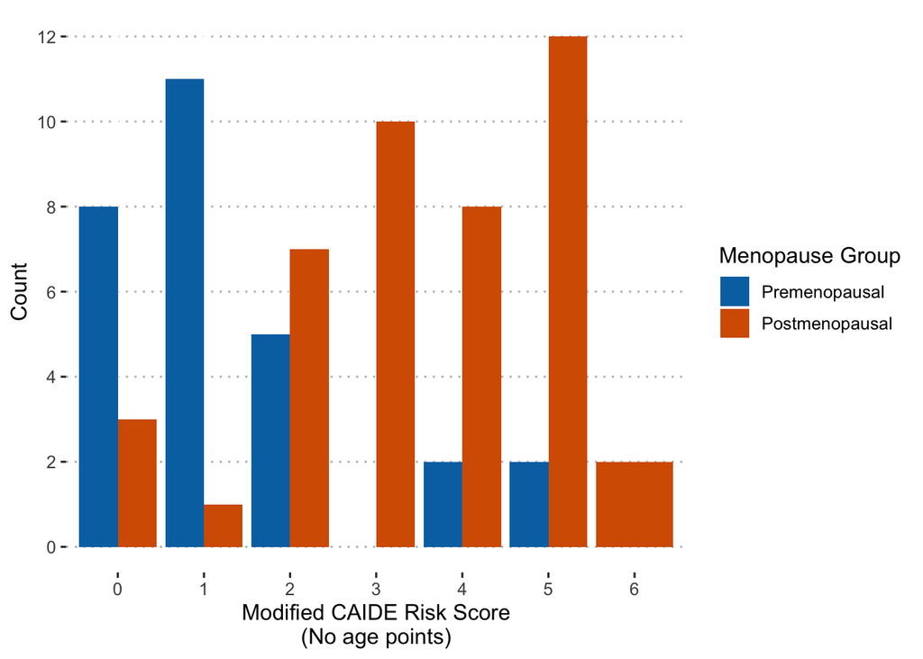

```r
cleaned_data_df$CAIDE_no_age <- as.factor(cleaned_data_df$CAIDE_no_age)

sup_caide_p <- ggplot(cleaned_data_df, aes(x = CAIDE_no_age, fill = group_var)) +
  geom_histogram(position = "dodge", stat = "count") +
  scale_fill_manual(name = "Menopause Group",
                    labels = c("Premenopausal", "Postmenopausal"),
                    values = c("#0072B2", "#D55E00")) +
  scale_y_continuous(limits = c(0, 12), breaks = seq(0, 12, 2)) +
  labs(x = "Modified CAIDE Risk Score\n(No age points)", y = "Count") +
  theme_pubclean() +
  theme(legend.position = "right")

sup_caide_p
```

## 4 Sup2 (Table S1): LRT for Models Predicting CS from CAIDE score (Analysis #3 in paper) — Premenopausal

```r
contrasts(cs_acc_CAIDE_pre$task) <- contr.sum(2)

lmm_CAIDE_cs_pre_0 <- lmer(cs_rate ~ task + (1|id), data = cs_acc_CAIDE_pre, REML = FALSE)
lmm_CAIDE_cs_pre_1 <- lmer(cs_rate ~ task + CAIDE + (1|id), data = cs_acc_CAIDE_pre, REML = FALSE)
lmm_CAIDE_cs_pre_2 <- lmer(cs_rate ~ task * CAIDE + (1|id), data = cs_acc_CAIDE_pre, REML = FALSE)

lrt_pre <- anova(lmm_CAIDE_cs_pre_0, lmm_CAIDE_cs_pre_1, lmm_CAIDE_cs_pre_2)
as.data.frame(lrt_pre)
```

|  | npar | AIC | BIC | logLik | deviance | Chisq | Df | Pr(>Chisq) |
| --- | --- | --- | --- | --- | --- | --- | --- | --- |
| lmm_CAIDE_cs_pre_0 | 4 | -68.73294 | -59.00968 | 38.36647 | -76.73294 | NA | NA | NA |
| lmm_CAIDE_cs_pre_1 | 11 | -61.40738 | -34.66840 | 41.70369 | -83.40738 | 6.674442 | 7 | 0.4635451 |
| lmm_CAIDE_cs_pre_2 | 18 | -58.85187 | -15.09717 | 47.42593 | -94.85187 | 11.444483 | 7 | 0.1203718 |

```r
library(MuMIn)
r.squaredGLMM(lmm_CAIDE_cs_pre_0)
```

```
##            R2m       R2c
## [1,] 0.2804814 0.8039839
```

```r
r.squaredGLMM(lmm_CAIDE_cs_pre_1)
```

```
##            R2m       R2c
## [1,] 0.3724912 0.8041993
```

```r
r.squaredGLMM(lmm_CAIDE_cs_pre_2)
```

```
##            R2m       R2c
## [1,] 0.3960121 0.8509431
```

## 5 Sup2 (continued): Postmenopausal Group

```r
contrasts(cs_acc_CAIDE_post$task) <- contr.sum(2)

lmm_CAIDE_cs_post_0 <- lmer(cs_rate ~ task + (1|id), data = cs_acc_CAIDE_post, REML = FALSE)
lmm_CAIDE_cs_post_1 <- lmer(cs_rate ~ task + CAIDE + (1|id), data = cs_acc_CAIDE_post, REML = FALSE)
lmm_CAIDE_cs_post_2 <- lmer(cs_rate ~ task * CAIDE + (1|id), data = cs_acc_CAIDE_post, REML = FALSE)

lrt_post <- anova(lmm_CAIDE_cs_post_0, lmm_CAIDE_cs_post_1, lmm_CAIDE_cs_post_2)
as.data.frame(lrt_post)
```

|  | npar | AIC | BIC | logLik | deviance | Chisq | Df | Pr(>Chisq) |
| --- | --- | --- | --- | --- | --- | --- | --- | --- |
| lmm_CAIDE_cs_post_0 | 4 | -95.33566 | -85.51827 | 51.66783 | -103.3357 | NA | NA | NA |
| lmm_CAIDE_cs_post_1 | 10 | -99.89148 | -75.34801 | 59.94574 | -119.8915 | 16.555821 | 6 | 0.01106205 |
| lmm_CAIDE_cs_post_2 | 16 | -92.74609 | -53.47653 | 62.37304 | -124.7461 | 4.854609 | 6 | 0.56259151 |

## 6 Sup3 (Table S2): Novelty Detection Models — Premenopausal

```r
contrasts(cr_acc_CAIDE_pre$task) <- contr.sum(2)

lmm_CAIDE_cr_pre_0 <- lmer(cr_rate ~ task + (1|id), data = cr_acc_CAIDE_pre, REML = FALSE)
lmm_CAIDE_cr_pre_1 <- lmer(cr_rate ~ task + CAIDE + (1|id), data = cr_acc_CAIDE_pre, REML = FALSE)
lmm_CAIDE_cr_pre_2 <- lmer(cr_rate ~ task * CAIDE + (1|id), data = cr_acc_CAIDE_pre, REML = FALSE)

anova(lmm_CAIDE_cr_pre_0, lmm_CAIDE_cr_pre_1, lmm_CAIDE_cr_pre_2)
```

|  | npar | AIC | BIC | logLik | deviance | Chisq | Df | Pr(>Chisq) |
| --- | --- | --- | --- | --- | --- | --- | --- | --- |
| lmm_CAIDE_cr_pre_0 | 4 | -147.3830 | -137.65971 | 77.69149 | -155.3830 | NA | NA | NA |
| lmm_CAIDE_cr_pre_1 | 11 | -140.0296 | -113.29064 | 81.01481 | -162.0296 | 6.646650 | 7 | 0.4665734 |
| lmm_CAIDE_cr_pre_2 | 18 | -135.9080 | -92.15332 | 85.95401 | -171.9080 | 9.878395 | 7 | 0.1955701 |

## 7 Sup3 (continued): Postmenopausal Group

```r
contrasts(cr_acc_CAIDE_post$task) <- contr.sum(2)

lmm_CAIDE_cr_post_0 <- lmer(cr_rate ~ task + (1|id), data = cr_acc_CAIDE_post, REML = FALSE)
lmm_CAIDE_cr_post_1 <- lmer(cr_rate ~ task + CAIDE + (1|id), data = cr_acc_CAIDE_post, REML = FALSE)
lmm_CAIDE_cr_post_2 <- lmer(cr_rate ~ task * CAIDE + (1|id), data = cr_acc_CAIDE_post, REML = FALSE)

anova(lmm_CAIDE_cr_post_0, lmm_CAIDE_cr_post_1, lmm_CAIDE_cr_post_2)
```

|  | npar | AIC | BIC | logLik | deviance | Chisq | Df | Pr(>Chisq) |
| --- | --- | --- | --- | --- | --- | --- | --- | --- |
| lmm_CAIDE_cr_post_0 | 4 | -89.93887 | -80.12148 | 48.96944 | -97.93887 | NA | NA | NA |
| lmm_CAIDE_cr_post_1 | 10 | -85.67319 | -61.12971 | 52.83659 | -105.67319 | 7.734314 | 6 | 0.2582215 |
| lmm_CAIDE_cr_post_2 | 16 | -76.21025 | -36.94069 | 54.10512 | -108.21025 | 2.537059 | 6 | 0.8642973 |

## 8 Sup4 (Table S3): Between-Group Mixed-Effect Linear Regressions — CS and CR

### 8.1 Model 1.1a: CS Accuracy

```r
sup_4_lmm_meno_cs <- lmer(cs_rate ~ task * group_var + edu_std + (1|id), data = meno_cs_acc, REML = TRUE)
anova(sup_4_lmm_meno_cs, type = "III")
```

|  | npar | Sum Sq | Mean Sq | F value |
| --- | --- | --- | --- | --- |
| task | 1 | 1.54270606 | 1.54270606 | 180.759155 |
| group_var | 1 | 0.20220881 | 0.20220881 | 23.692844 |
| edu_std | 1 | 0.02644009 | 0.02644009 | 3.097990 |
| task:group_var | 1 | 0.06359273 | 0.06359273 | 7.451172 |

```r
summary(sup_4_lmm_meno_cs)$coefficients
```

```
##                    Estimate  Std. Error   t value
## (Intercept)      0.44109325 0.017229936 25.600400
## task1            0.09548900 0.007085933 13.475854
## group_var1       0.07625935 0.017763708  4.292986
## edu_std          0.03144947 0.017867894  1.760111
## task1:group_var1 0.01934235 0.007085933  2.729683
```

```r
sjPlot::tab_model(sup_4_lmm_meno_cs,
                  dv.labels = "Task and Menopause Status predicting CS", p.style = "scientific_stars", df.method = "satterthwaite")
```

Task and Menopause Status predicting CS

Predictors

Estimates

CI

p

(Intercept)

0.44 ***

0.41 – 0.48

**7.239e-41**

task1

0.10 ***

0.08 – 0.11

**1.333e-22**

group var1

0.08 ***

0.04 – 0.11

**4.801e-05**

edu std

0.03

-0.00 – 0.07

8.212e-02

task1 × group var1

0.02 **

0.01 – 0.03

**7.739e-03**

Random Effects

σ<sup>2</sup>

0.01

τ<sub>00</sub> <sub>id</sub>

0.02

ICC

0.71

N <sub>id</sub>

85

Observations

170

Marginal R<sup>2</sup> / Conditional R<sup>2</sup>

0.372 / 0.818

- p<0.05 ** p<0.01 *** p<0.001

```r
check_collinearity(sup_4_lmm_meno_cs)
```

| Term | VIF | VIF_CI_low | VIF_CI_high | SE_factor | Tolerance | Tolerance_CI_low | Tolerance_CI_high |
| --- | --- | --- | --- | --- | --- | --- | --- |
| task | 1.000138 | 1.000000 | Inf | 1.000069 | 0.9998616 | 0.0000000 | 1.0000000 |
| group_var | 1.062928 | 1.004807 | 1.823836 | 1.030984 | 0.9407978 | 0.5482949 | 0.9952163 |
| edu_std | 1.062928 | 1.004807 | 1.823836 | 1.030984 | 0.9407978 | 0.5482949 | 0.9952163 |
| task:group_var | 1.000138 | 1.000000 | Inf | 1.000069 | 0.9998616 | 0.0000000 | 1.0000000 |

```r
sup_4_out_EM_means_lmm_meno_cs <- bind_rows(
  as.data.frame(emmeans(sup_4_lmm_meno_cs, pairwise ~ task)),
  as.data.frame(emmeans(sup_4_lmm_meno_cs, pairwise ~ group_var))
)
sup_4_out_EM_means_lmm_meno_cs
```

| task | contrast | emmean | SE | df | lower.CL | upper.CL | group_var |
| --- | --- | --- | --- | --- | --- | --- | --- |
| easy | . | 0.5365822 | 0.01863011 | 109.0028 | 0.49128335 | 0.5818811 | NA |
| hard | . | 0.3456043 | 0.01863011 | 109.0028 | 0.30030536 | 0.3909031 | NA |
| . | easy - hard | 0.1909780 | 0.01417187 | 83.0000 | 0.15634949 | 0.2256065 | NA |
| NA | . | 0.5173526 | 0.02489668 | 82.0000 | 0.45650303 | 0.5782022 | pre |
| NA | . | 0.3648339 | 0.02459665 | 82.0000 | 0.30471763 | 0.4249502 | post |
| NA | pre - post | 0.1525187 | 0.03552742 | 82.0000 | 0.06568673 | 0.2393507 | . |

```r
sup_4_out_EM_contrasts_lmm_meno_cs <- as.data.frame(emmeans(sup_4_lmm_meno_cs, pairwise ~ group_var | task))
sup_4_out_EM_contrasts_lmm_meno_cs
```

|  | task | group_var | contrast | emmean | SE | df | lower.CL | upper.CL |
| --- | --- | --- | --- | --- | --- | --- | --- | --- |
| 1 | easy | pre | . | 0.6321839 | 0.02685977 | 108.2129 | 0.55999498 | 0.7043729 |
| 2 | easy | post | . | 0.4409805 | 0.02653742 | 108.2308 | 0.36965814 | 0.5123029 |
| 3 | hard | pre | . | 0.4025212 | 0.02685977 | 108.2129 | 0.33033228 | 0.4747102 |
| 4 | hard | post | . | 0.2886873 | 0.02653742 | 108.2308 | 0.21736486 | 0.3600097 |
| 5 | easy | . | pre - post | 0.1912034 | 0.03824969 | 107.4834 | 0.08838955 | 0.2940173 |
| 6 | hard | . | pre - post | 0.1138340 | 0.03824969 | 107.4834 | 0.01102013 | 0.2166478 |

#### 8.1.1 Plot: Main Effects — CS

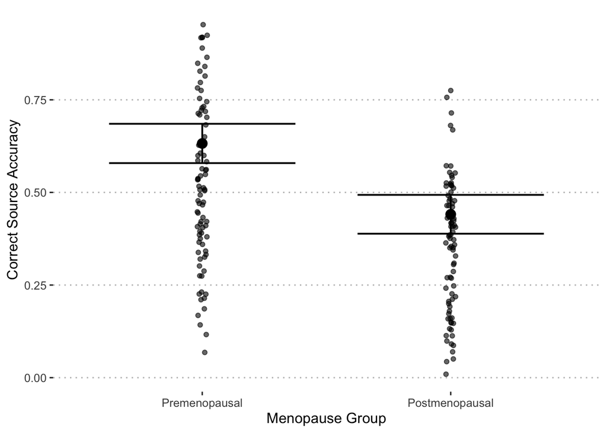

```r
effect_plot(sup_4_lmm_meno_cs, pred = group_var, plot.points = TRUE, jitter = 0.02,
            line.thickness = 0.7, x.label = "Menopause Group", y.label = "Correct Source Accuracy") +
  scale_x_discrete(labels = c("Premenopausal", "Postmenopausal")) +
  theme_pubclean()
```

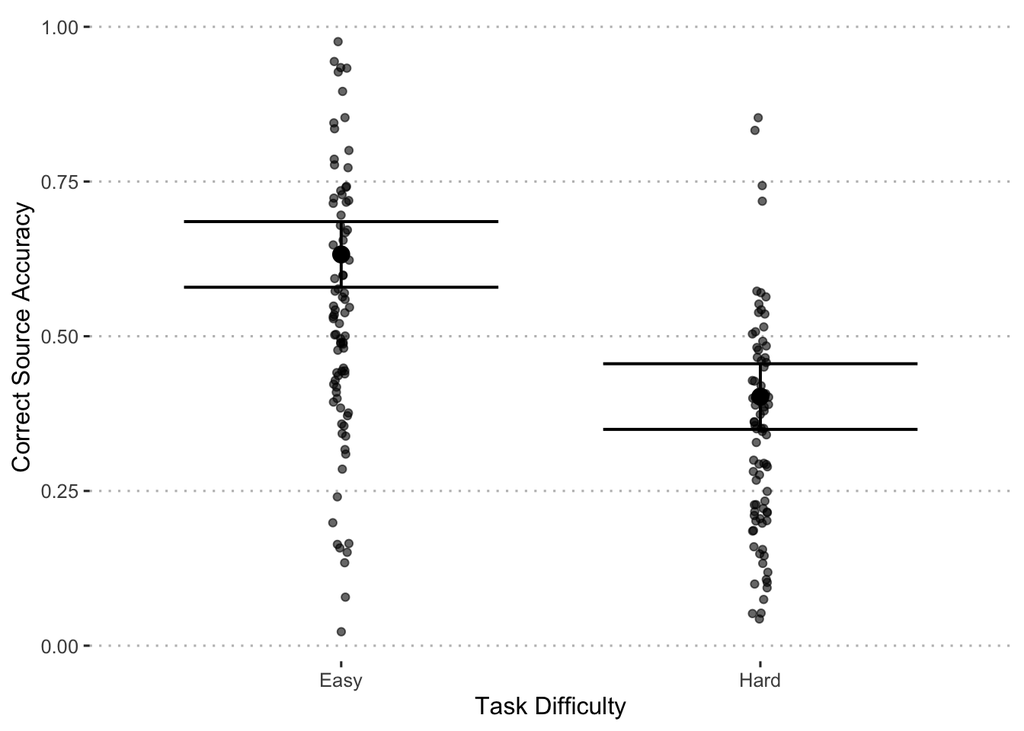

```r
effect_plot(sup_4_lmm_meno_cs, pred = task, plot.points = TRUE, jitter = 0.02,
            line.thickness = 0.7, x.label = "Task Difficulty", y.label = "Correct Source Accuracy") +
  scale_x_discrete(labels = c("Easy", "Hard")) +
  theme_pubclean()
```

### 8.2 Model 1.1b: CR Accuracy

```r
sup_4_lmm_meno_cr <- lmer(cr_rate ~ task * group_var + edu_std + (1|id), data = meno_cr_acc, REML = TRUE)
anova(sup_4_lmm_meno_cr, type = "III")
```

|  | npar | Sum Sq | Mean Sq | F value |
| --- | --- | --- | --- | --- |
| task | 1 | 7.465533e-02 | 7.465533e-02 | 1.939918e+01 |
| group_var | 1 | 2.442513e-02 | 2.442513e-02 | 6.346867e+00 |
| edu_std | 1 | 1.002962e-03 | 1.002962e-03 | 2.606195e-01 |
| task:group_var | 1 | 2.613893e-06 | 2.613893e-06 | 6.792198e-04 |

```r
summary(sup_4_lmm_meno_cr)$coefficients
```

```
##                       Estimate  Std. Error     t value
## (Intercept)       0.7929193297 0.017923044 44.24021456
## task1             0.0209573413 0.004758218  4.40445195
## group_var1        0.0474485801 0.018478288  2.56780170
## edu_std          -0.0094886624 0.018586666 -0.51050911
## task1:group_var1  0.0001240079 0.004758218  0.02606185
```

```r
sjPlot::tab_model(sup_4_lmm_meno_cr,
                  dv.labels = "Task and Menopause Status Predicting CR", p.style = "scientific_stars")
```

Task and Menopause Status Predicting CR

Predictors

Estimates

CI

p

(Intercept)

0.79 ***

0.76 – 0.83

**1.014e-92**

task1

0.02 ***

0.01 – 0.03

**1.914e-05**

group var1

0.05 *

0.01 – 0.08

**1.113e-02**

edu std

-0.01

-0.05 – 0.03

6.104e-01

task1 × group var1

0.00

-0.01 – 0.01

9.792e-01

Random Effects

σ<sup>2</sup>

0.00

τ<sub>00</sub> <sub>id</sub>

0.03

ICC

0.87

N <sub>id</sub>

85

Observations

170

Marginal R<sup>2</sup> / Conditional R<sup>2</sup>

0.081 / 0.879

- p<0.05 ** p<0.01 *** p<0.001

```r
check_collinearity(sup_4_lmm_meno_cr)
```

| Term | VIF | VIF_CI_low | VIF_CI_high | SE_factor | Tolerance | Tolerance_CI_low | Tolerance_CI_high |
| --- | --- | --- | --- | --- | --- | --- | --- |
| task | 1.000138 | 1.000000 | Inf | 1.000069 | 0.9998616 | 0.0000000 | 1.0000000 |
| group_var | 1.062928 | 1.004807 | 1.823836 | 1.030984 | 0.9407978 | 0.5482949 | 0.9952163 |
| edu_std | 1.062928 | 1.004807 | 1.823836 | 1.030984 | 0.9407978 | 0.5482949 | 0.9952163 |
| task:group_var | 1.000138 | 1.000000 | Inf | 1.000069 | 0.9998616 | 0.0000000 | 1.0000000 |

```r
sup_4_out_EM_means_lmm_meno_cr <- bind_rows(
  as.data.frame(emmeans(sup_4_lmm_meno_cr, pairwise ~ task)),
  as.data.frame(emmeans(sup_4_lmm_meno_cr, pairwise ~ group_var))
)
sup_4_out_EM_means_lmm_meno_cr
```

| task | contrast | emmean | SE | df | lower.CL | upper.CL | group_var |
| --- | --- | --- | --- | --- | --- | --- | --- |
| easy | . | 0.81387667 | 0.018543898 | 93.50713 | 0.768670154 | 0.85908319 | NA |
| hard | . | 0.77196199 | 0.018543898 | 93.50713 | 0.726755471 | 0.81716851 | NA |
| . | easy - hard | 0.04191468 | 0.009516435 | 83.00000 | 0.018661578 | 0.06516779 | NA |
| NA | . | 0.84036791 | 0.025898199 | 82.00000 | 0.777070554 | 0.90366527 | pre |
| NA | . | 0.74547075 | 0.025586102 | 82.00000 | 0.682936185 | 0.80800531 | post |
| NA | pre - post | 0.09489716 | 0.036956577 | 82.00000 | 0.004572208 | 0.18522211 | . |

```r
sup_4_out_EM_contrasts_lmm_meno_cr <- as.data.frame(emmeans(sup_4_lmm_meno_cr, pairwise ~ group_var | task))
sup_4_out_EM_contrasts_lmm_meno_cr
```

|  | task | group_var | contrast | emmean | SE | df | lower.CL | upper.CL |
| --- | --- | --- | --- | --- | --- | --- | --- | --- |
| 1 | easy | pre | . | 0.86144926 | 0.02676809 | 93.15538 | 0.789288755 | 0.9336098 |
| 2 | easy | post | . | 0.76630408 | 0.02644612 | 93.16332 | 0.695011675 | 0.8375965 |
| 3 | hard | pre | . | 0.81928656 | 0.02676809 | 93.15538 | 0.747126056 | 0.8914471 |
| 4 | hard | post | . | 0.72463742 | 0.02644612 | 93.16332 | 0.653345008 | 0.7959298 |
| 5 | easy | . | pre - post | 0.09514518 | 0.03816217 | 92.83179 | -0.007738898 | 0.1980292 |
| 6 | hard | . | pre - post | 0.09464914 | 0.03816217 | 92.83179 | -0.008234929 | 0.1975332 |

#### 8.2.1 Plot: Main Effects — CR

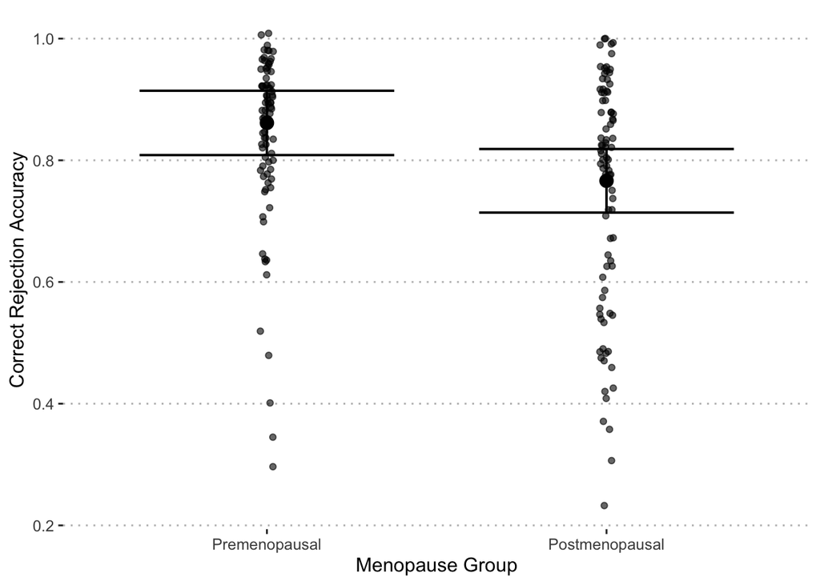

```r
effect_plot(sup_4_lmm_meno_cr, pred = group_var, plot.points = TRUE, jitter = 0.02,
            line.thickness = 0.7, x.label = "Menopause Group", y.label = "Correct Rejection Accuracy") +
  scale_x_discrete(labels = c("Premenopausal", "Postmenopausal")) +
  theme_pubclean()
```

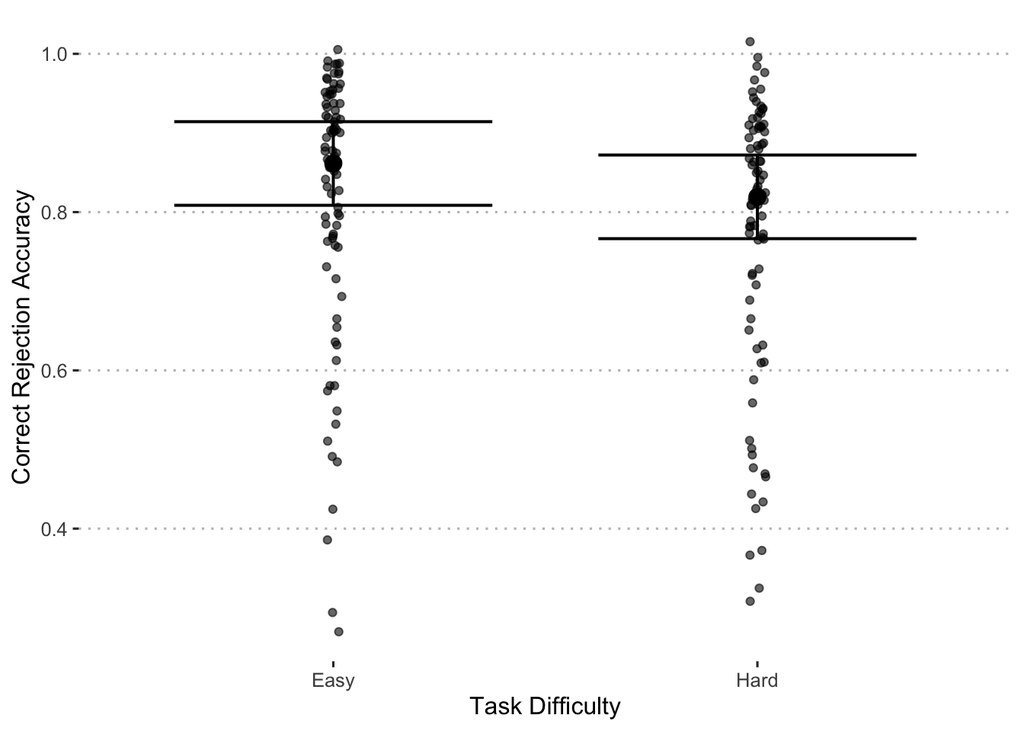

```r
effect_plot(sup_4_lmm_meno_cr, pred = task, plot.points = TRUE, jitter = 0.02,
            line.thickness = 0.7, x.label = "Task Difficulty", y.label = "Correct Rejection Accuracy") +
  scale_x_discrete(labels = c("Easy", "Hard")) +
  theme_pubclean()
```

## 9 Sup5 (Table S4): Stepwise Regression — CS

```r
full.model_cs <- lmer(cs_rate ~ task * group_var * s2_age_std + edu_std + (1|id), data = meno_cs_acc, REML=TRUE)
fixmodel_cs <- lm(formula(full.model_cs, fixed.only=TRUE), data=eval(getCall(full.model_cs)$data))
step(fixmodel_cs)
```

```
## Start:  AIC=-601.4
## cs_rate ~ task * group_var * s2_age_std + edu_std
##
##                             Df Sum of Sq    RSS     AIC
## - task:group_var:s2_age_std  1  0.013987 4.4611 -602.87
## <none>                                   4.4472 -601.40
## - edu_std                    1  0.147699 4.5949 -597.85
##
## Step:  AIC=-602.87
## cs_rate ~ task + group_var + s2_age_std + edu_std + task:group_var +
##     task:s2_age_std + group_var:s2_age_std
##
##                        Df Sum of Sq    RSS     AIC
## - group_var:s2_age_std  1  0.001132 4.4623 -604.82
## - task:s2_age_std       1  0.009770 4.4709 -604.49
## - task:group_var        1  0.044062 4.5052 -603.20
## <none>                              4.4611 -602.87
## - edu_std               1  0.147699 4.6088 -599.33
##
## Step:  AIC=-604.82
## cs_rate ~ task + group_var + s2_age_std + edu_std + task:group_var +
##     task:s2_age_std
##
##                   Df Sum of Sq    RSS     AIC
## - task:s2_age_std  1  0.009770 4.4721 -606.45
## - task:group_var   1  0.044062 4.5063 -605.15
## <none>                         4.4623 -604.82
## - edu_std          1  0.147569 4.6098 -601.29
##
## Step:  AIC=-606.45
## cs_rate ~ task + group_var + s2_age_std + edu_std + task:group_var
##
##                  Df Sum of Sq    RSS     AIC
## <none>                        4.4721 -606.45
## - task:group_var  1   0.06359 4.5356 -606.05
## - edu_std         1   0.14757 4.6196 -602.93
## - s2_age_std      1   0.37409 4.8461 -594.79
```

```
##
## Call:
## lm(formula = cs_rate ~ task + group_var + s2_age_std + edu_std +
##     task:group_var, data = eval(getCall(full.model_cs)$data))
##
## Coefficients:
##      (Intercept)             task1        group_var1        s2_age_std
##         0.440116          0.095489         -0.006796         -0.096140
##          edu_std  task1:group_var1
##         0.030561          0.019342
```

```r
stepwise_cs <- lmer(cs_rate ~ task + group_var + s2_age_std + edu_std + task:group_var + (1|id), data = meno_cs_acc, REML=TRUE)
sjPlot::tab_model(stepwise_cs, dv.labels = "Stepwise model predicting CS", p.style = "scientific_stars", df.method = "satterthwaite")
```

Stepwise model predicting CS

Predictors

Estimates

CI

p

(Intercept)

0.44 ***

0.41 – 0.47

**8.416e-42**

task1

0.10 ***

0.08 – 0.11

**1.333e-22**

group var1

-0.01

-0.07 – 0.06

8.415e-01

s2 age std

-0.10 **

-0.16 – -0.03

**5.745e-03**

edu std

0.03

-0.00 – 0.06

7.848e-02

task1 × group var1

0.02 **

0.01 – 0.03

**7.739e-03**

Random Effects

σ<sup>2</sup>

0.01

τ<sub>00</sub> <sub>id</sub>

0.02

ICC

0.69

N <sub>id</sub>

85

Observations

170

Marginal R<sup>2</sup> / Conditional R<sup>2</sup>

0.418 / 0.819

- p<0.05 ** p<0.01 *** p<0.001

## 10 Sup6 (Table S5): Stepwise Regression — CR

```r
full.model_cr <- lmer(cr_rate ~ task * group_var * s2_age_std + edu_std + (1|id), data = meno_cr_acc, REML=TRUE)
fixmodel_cr <- lm(formula(full.model_cr, fixed.only=TRUE), data=eval(getCall(full.model_cr)$data))
step(fixmodel_cr)
```

```
## Start:  AIC=-589.91
## cr_rate ~ task * group_var * s2_age_std + edu_std
##
##                             Df Sum of Sq    RSS     AIC
## - task:group_var:s2_age_std  1 0.0014164 4.7595 -591.86
## - edu_std                    1 0.0150780 4.7732 -591.37
## <none>                                   4.7581 -589.91
##
## Step:  AIC=-591.86
## cr_rate ~ task + group_var + s2_age_std + edu_std + task:group_var +
##     task:s2_age_std + group_var:s2_age_std
##
##                        Df Sum of Sq    RSS     AIC
## - task:group_var        1 0.0015162 4.7610 -593.81
## - task:s2_age_std       1 0.0020799 4.7616 -593.79
## - group_var:s2_age_std  1 0.0060410 4.7655 -593.65
## - edu_std               1 0.0150780 4.7746 -593.32
## <none>                              4.7595 -591.86
##
## Step:  AIC=-593.81
## cr_rate ~ task + group_var + s2_age_std + edu_std + task:s2_age_std +
##     group_var:s2_age_std
##
##                        Df Sum of Sq    RSS     AIC
## - task:s2_age_std       1 0.0005663 4.7616 -595.79
## - group_var:s2_age_std  1 0.0060410 4.7671 -595.59
## - edu_std               1 0.0150780 4.7761 -595.27
## <none>                              4.7610 -593.81
##
## Step:  AIC=-595.79
## cr_rate ~ task + group_var + s2_age_std + edu_std + group_var:s2_age_std
##
##                        Df Sum of Sq    RSS     AIC
## - group_var:s2_age_std  1  0.006041 4.7676 -597.57
## - edu_std               1  0.015078 4.7767 -597.25
## <none>                              4.7616 -595.79
## - task                  1  0.074655 4.8362 -595.14
##
## Step:  AIC=-597.57
## cr_rate ~ task + group_var + s2_age_std + edu_std
```

[output cut: 9 more lines]

```
## cr_rate ~ task + group_var + s2_age_std
##
##              Df Sum of Sq    RSS     AIC
## - group_var   1  0.020207 4.8028 -600.32
## - s2_age_std  1  0.028408 4.8110 -600.03
## <none>                    4.7826 -599.04
## - task        1  0.074655 4.8573 -598.41
##
## Step:  AIC=-600.32
## cr_rate ~ task + s2_age_std
##
##              Df Sum of Sq    RSS     AIC
## <none>                    4.8028 -600.32
## - task        1   0.07466 4.8775 -599.70
## - s2_age_std  1   0.35475 5.1576 -590.21
```

```
##
## Call:
## lm(formula = cr_rate ~ task + s2_age_std, data = eval(getCall(full.model_cr)$data))
##
## Coefficients:
## (Intercept)        task1   s2_age_std
##     0.79236      0.02096     -0.04595
```

```r
stepwise_cr <- lmer(cr_rate ~ task + s2_age_std + (1|id), data = meno_cr_acc, REML=TRUE)
sjPlot::tab_model(stepwise_cr, dv.labels = "Stepwise model predicting CR", p.style = "scientific_stars", df.method = "satterthwaite")
```

Stepwise model predicting CR

Predictors

Estimates

CI

p

(Intercept)

0.79 ***

0.76 – 0.83

**1.180e-59**

task1

0.02 ***

0.01 – 0.03

**2.814e-05**

s2 age std

-0.05 *

-0.08 – -0.01

**1.219e-02**

Random Effects

σ<sup>2</sup>

0.00

τ<sub>00</sub> <sub>id</sub>

0.03

ICC

0.87

N <sub>id</sub>

85

Observations

170

Marginal R<sup>2</sup> / Conditional R<sup>2</sup>

0.081 / 0.879

- p<0.05 ** p<0.01 *** p<0.001

## 11 Sup7 (Table S6): Post Hoc — Interaction Between Age at FMP and CAIDE (CS)

```r
age_FMP <- cleaned_data_df %>%
  select(id, group_var, CAIDE, edu, s2_age, s2_fmp_mths) %>%
  filter(group_var == "post") %>%
  mutate(age_fmp = s2_age - s2_fmp_mths / 12)

cor.test(age_FMP$s2_age, age_FMP$age_fmp)
```

```
##
##  Pearson's product-moment correlation
##
## data:  age_FMP$s2_age and age_FMP$age_fmp
## t = 1.2474, df = 39, p-value = 0.2197
## alternative hypothesis: true correlation is not equal to 0
## 95 percent confidence interval:
##  -0.1189455  0.4749052
## sample estimates:
##       cor
## 0.1958726
```

```r
cor.test(as.numeric(age_FMP$CAIDE), age_FMP$age_fmp)
```

```
##
##  Pearson's product-moment correlation
##
## data:  as.numeric(age_FMP$CAIDE) and age_FMP$age_fmp
## t = 1.2842, df = 39, p-value = 0.2067
## alternative hypothesis: true correlation is not equal to 0
## 95 percent confidence interval:
##  -0.1132478  0.4793659
## sample estimates:
##       cor
## 0.2014203
```

Create df: Merge FMP data with cs dataframe

```r
x <- age_FMP %>% select(id, s2_age, edu, age_fmp)
fmp_age_cs_df <- merge(x, cs_acc_CAIDE_post, by = "id",all=FALSE)
fmp_age_cs_df$s2_age_bin_2 <- as.numeric(cut_number(fmp_age_cs_df$s2_age,3))
```

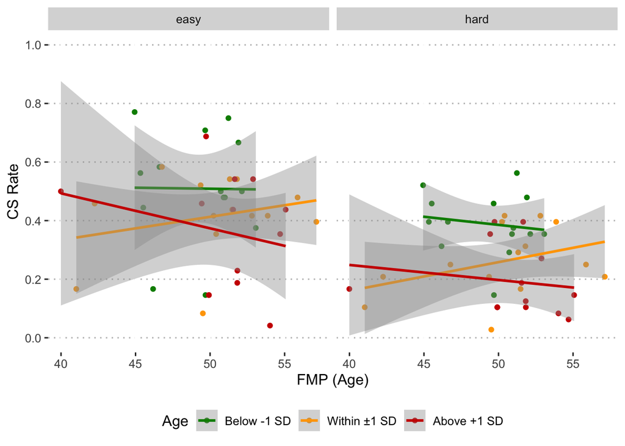

```r
age_fmp_CS_plot <- ggplot(fmp_age_cs_df, aes(x = age_fmp, y = cs_rate, color = as.factor(s2_age_bin_2))) +
  facet_grid(~task) +
  geom_point() +
  geom_smooth(method = lm) +
  scale_y_continuous(name = "CS Rate", limits = c(0, 1), breaks = seq(0, 1, 0.2)) +
  scale_x_continuous(name = "FMP (Age)") +
  scale_colour_manual(values = c("green4", "orange", "red3"), labels = c("Below -1 SD", "Within ±1 SD", "Above +1 SD")) +
  labs(colour = "Age") +
  theme_pubclean() +
  theme(legend.position = "bottom")

age_fmp_CS_plot
```

```r
cs_acc_CAIDE_fmp_post <- merge(cs_acc_CAIDE_post, age_FMP %>% select(id, age_fmp), by = "id") %>%
  na.omit() %>%
  mutate(CAIDE = factor(CAIDE, levels = c("4","5","6","7","8","9","10")))

r_helmert_1 <- matrix(c(
  -1/2, 1/2, 0, 0, 0, 0, 0,
  -1/3, -1/3, 2/3, 0, 0, 0, 0,
  -1/4, -1/4, -1/4, 3/4, 0, 0, 0,
  -1/5, -1/5, -1/5, -1/5, 4/5, 0, 0,
  -1/6, -1/6, -1/6, -1/6, -1/6, 5/6, 0,
  -1/7, -1/7, -1/7, -1/7, -1/7, -1/7, 6/7
), ncol = 6)

contrasts(cs_acc_CAIDE_fmp_post$task) <- contr.sum(2)
contrasts(cs_acc_CAIDE_fmp_post$CAIDE) <- r_helmert_1
```

```r
lmm_CAIDE_cs_post_fmp0 <- lmer(cs_rate ~ task + CAIDE + (1|id), data = cs_acc_CAIDE_fmp_post, REML=FALSE)
lmm_CAIDE_cs_post_fmp1 <- lmer(cs_rate ~ task + CAIDE + age_fmp + (1|id), data = cs_acc_CAIDE_fmp_post, REML=FALSE)
lmm_CAIDE_cs_post_fmp2 <- lmer(cs_rate ~ task + CAIDE * age_fmp + (1|id), data = cs_acc_CAIDE_fmp_post, REML=FALSE)

anova(lmm_CAIDE_cs_post_fmp0, lmm_CAIDE_cs_post_fmp1, lmm_CAIDE_cs_post_fmp2)
```

|  | npar | AIC | BIC | logLik | deviance | Chisq | Df | Pr(>Chisq) |
| --- | --- | --- | --- | --- | --- | --- | --- | --- |
| lmm_CAIDE_cs_post_fmp0 | 10 | -92.90554 | -68.83835 | 56.45277 | -112.9055 | NA | NA | NA |
| lmm_CAIDE_cs_post_fmp1 | 11 | -92.27230 | -65.79838 | 57.13615 | -114.2723 | 1.366755 | 1 | 0.24237015 |
| lmm_CAIDE_cs_post_fmp2 | 15 | -92.42101 | -56.32022 | 61.21050 | -122.4210 | 8.148712 | 4 | 0.08628008 |

```r
lmm_CAIDE_cs_post_fmp2 <- lmer(cs_rate ~ task + CAIDE * age_fmp + (1|id), data = cs_acc_CAIDE_fmp_post, REML=TRUE)
anova(lmm_CAIDE_cs_post_fmp2, type = "III")
```

|  | npar | Sum Sq | Mean Sq | F value |
| --- | --- | --- | --- | --- |
| task | 1 | 0.445143123 | 0.445143123 | 59.441164 |
| CAIDE | 6 | 0.130640303 | 0.021773384 | 2.907459 |
| age_fmp | 1 | 0.008980318 | 0.008980318 | 1.199166 |
| CAIDE:age_fmp | 4 | 0.047751594 | 0.011937898 | 1.594100 |

```r
summary(lmm_CAIDE_cs_post_fmp2)$coefficients
```

```
##                    Estimate  Std. Error    t value
## (Intercept)     1.057710294 0.492695519  2.1467829
## task1           0.073678862 0.009556509  7.7098096
## CAIDE1          4.468161938 3.145090288  1.4206784
## CAIDE2         -1.313099474 1.926511413 -0.6815944
## CAIDE3         -0.473262726 1.150399063 -0.4113900
## CAIDE4          0.768862684 1.024118560  0.7507555
## CAIDE5         -0.161839501 0.052683074 -3.0719449
## CAIDE6          0.277090542 0.133603158  2.0739820
## age_fmp        -0.012472304 0.009833299 -1.2683743
## CAIDE1:age_fmp -0.086809583 0.063601378 -1.3649010
## CAIDE2:age_fmp  0.024641129 0.038600437  0.6383640
## CAIDE3:age_fmp  0.007507157 0.023094668  0.3250602
## CAIDE4:age_fmp -0.014171425 0.020174417 -0.7024453
```

```r
sjPlot::tab_model(lmm_CAIDE_cs_post_fmp2, dv.labels = "Task, CAIDE and FMP predicting CS", p.style = "scientific_stars", df.method = "satterthwaite")
```

Task, CAIDE and FMP predicting CS

Predictors

Estimates

CI

p

(Intercept)

1.06 *

0.05 – 2.07

**4.031e-02**

task1

0.07 ***

0.05 – 0.09

**1.964e-09**

CAIDE1

4.47

-1.96 – 10.90

1.661e-01

CAIDE2

-1.31

-5.25 – 2.63

5.009e-01

CAIDE3

-0.47

-2.83 – 1.88

6.838e-01

CAIDE [4]

0.77

-1.33 – 2.86

4.588e-01

CAIDE [5]

-0.16 **

-0.27 – -0.05

**4.592e-03**

CAIDE [6]

0.28 *

0.00 – 0.55

**4.707e-02**

age fmp

-0.01

-0.03 – 0.01

2.148e-01

CAIDE1 × age fmp

-0.09

-0.22 – 0.04

1.828e-01

CAIDE2 × age fmp

0.02

-0.05 – 0.10

5.282e-01

CAIDE3 × age fmp

0.01

-0.04 – 0.05

7.475e-01

CAIDE [4] × age fmp

-0.01

-0.06 – 0.03

4.880e-01

Random Effects

σ<sup>2</sup>

0.01

τ<sub>00</sub> <sub>id</sub>

0.01

ICC

0.63

N <sub>id</sub>

41

Observations

82

Marginal R<sup>2</sup> / Conditional R<sup>2</sup>

0.436 / 0.794

- p<0.05 ** p<0.01 *** p<0.001

## 12 Sup8 (Table S7): Mediation Analysis — CAIDE

```r
meno_cs_CAIDE_acc <- cleaned_data_df %>%
  select(id, group_var, CAIDE_no_age, cs_rate_easy, cs_rate_hard) %>%
  pivot_longer(!c(id, group_var, CAIDE_no_age), names_to = "task", values_to = "cs_rate") %>%
  mutate(task = str_replace_all(task, "cs_rate_", ""),
         task = factor(task, levels = c("easy", "hard")),
         CAIDE_no_age = factor(CAIDE_no_age, levels = c("0","1","2","3","4","5","6")))

r_helmert_1 <- matrix(c(
  -1/2, 1/2, 0, 0, 0, 0, 0,
  -1/3, -1/3, 2/3, 0, 0, 0, 0,
  -1/4, -1/4, -1/4, 3/4, 0, 0, 0,
  -1/5, -1/5, -1/5, -1/5, 4/5, 0, 0,
  -1/6, -1/6, -1/6, -1/6, -1/6, 5/6, 0,
  -1/7, -1/7, -1/7, -1/7, -1/7, -1/7, 6/7
), ncol = 6)

contrasts(meno_cs_CAIDE_acc$task) <- contr.sum(2)
contrasts(meno_cs_CAIDE_acc$group_var) <- contr.sum(2)
contrasts(meno_cs_CAIDE_acc$CAIDE_no_age) <- r_helmert_1
```

### 12.1 CAIDE as factor (Table S7)

```r
# Required libraries
library(nnet)
library(lme4)
library(sjPlot)

# Path a: group_var → CAIDE_no_age
path_a <- multinom(CAIDE_no_age ~ group_var, data = meno_cs_CAIDE_acc)
summary(path_a)
```

```
## Call:
## multinom(formula = CAIDE_no_age ~ group_var, data = meno_cs_CAIDE_acc)
##
## Coefficients:
##     (Intercept) group_var1
## 1 -0.3900049586  0.7084607
## 2  0.1886159931 -0.6586154
## 3  0.8817639817 -0.3221355
## 4 -0.2030255431 -1.1838158
## 5  0.0002524853 -1.3859863
## 6 -6.6900018728 -6.2844438
##
## Std. Errors:
##   (Intercept) group_var1
## 1   0.4400324  0.4400324
## 2   0.3164602  0.3164602
## 3   0.2805680  0.2805680
## 4   0.3680340  0.3680340
## 5   0.3607932  0.3607932
## 6  82.0881232 82.0881232
##
## Residual Deviance: 560.6041
## AIC: 584.6041
```

```r
a_coefs <- as.numeric(summary(path_a)$coefficients[, "group_var1"])

# Path b + c': CAIDE_no_age + group_var → cs_rate
path_b_c <- lmer(cs_rate ~ group_var + CAIDE_no_age + task + (1 | id),
                 data = meno_cs_CAIDE_acc, REML = TRUE)
summary(path_b_c)
```

```
## Linear mixed model fit by REML ['lmerMod']
## Formula: cs_rate ~ group_var + CAIDE_no_age + task + (1 | id)
##    Data: meno_cs_CAIDE_acc
##
## REML criterion at convergence: -135
##
## Scaled residuals:
##      Min       1Q   Median       3Q      Max
## -1.99386 -0.53867  0.06551  0.53119  1.65229
##
## Random effects:
##  Groups   Name        Variance Std.Dev.
##  id       (Intercept) 0.02098  0.14485
##  Residual             0.00919  0.09586
## Number of obs: 170, groups:  id, 85
##
## Fixed effects:
##                Estimate Std. Error t value
## (Intercept)    0.465013   0.022710  20.477
## group_var1     0.076955   0.020535   3.747
## CAIDE_no_age1  0.063180   0.067209   0.940
## CAIDE_no_age2  0.007851   0.059351   0.132
## CAIDE_no_age3 -0.009423   0.042612  -0.221
## CAIDE_no_age4  0.001006   0.058262   0.017
## CAIDE_no_age5 -0.085390   0.050412  -1.694
## CAIDE_no_age6  0.193388   0.116364   1.662
## task1          0.095261   0.007352  12.956
##
## Correlation of Fixed Effects:
##             (Intr) grp_v1 CAIDE__1 CAIDE__2 CAIDE__3 CAIDE__4 CAIDE__5 CAIDE__6
## group_var1   0.133
## CAIDE_no_g1 -0.033 -0.116
## CAIDE_no_g2  0.027  0.280 -0.008
## CAIDE_no_g3 -0.154  0.100  0.011    0.041
## CAIDE_no_g4  0.113  0.325 -0.025    0.098    0.146
## CAIDE_no_g5  0.019  0.347 -0.029    0.104    0.140    0.069
## CAIDE_no_g6  0.606  0.176 -0.016    0.052    0.056    0.041    0.067
## task1        0.000  0.000  0.000    0.000    0.000    0.000    0.000    0.000
```

```r
# Coefficients
fixef_coeffs <- fixef(path_b_c)
b_coef <- as.numeric(fixef_coeffs[grep("^CAIDE_no_age", names(fixef_coeffs))])
c_prime_coef <- as.numeric(fixef_coeffs[grep("^group_var", names(fixef_coeffs))])

# Indirect effect (Path a * b)
indirect_effects <- a_coefs * b_coef
total_indirect_effect <- sum(indirect_effects)

# Table S7 output
cat("=== Table S7 Mediation Summary ===\n")
```

```
## === Table S7 Mediation Summary ===
```

```r
cat("Indirect effects (a * b):\n"); print(indirect_effects)
```

```
## Indirect effects (a * b):
```

```
## [1]  0.044760431 -0.005170597  0.003035344 -0.001191108  0.118349742
## [6] -1.215337123
```

```r
cat("Total indirect effect:", total_indirect_effect, "\n")
```

```
## Total indirect effect: -1.055553
```

```r
cat("Direct effect (Path c′):", c_prime_coef, "\n")
```

```
## Direct effect (Path c′): 0.07695523
```

```r
sjPlot::tab_model(path_b_c,
  dv.labels = "CS Accuracy ~ CAIDE + Menopause + Task",
  p.style = "scientific_stars",
  df.method = "satterthwaite")
```

CS Accuracy ~ CAIDE + Menopause + Task

Predictors

Estimates

CI

p

(Intercept)

0.47 ***

0.42 – 0.51

**6.870e-33**

group var1

0.08 ***

0.04 – 0.12

**3.434e-04**

CAIDE no age [1]

0.06

-0.07 – 0.20

3.501e-01

CAIDE no age [2]

0.01

-0.11 – 0.13

8.951e-01

CAIDE no age [3]

-0.01

-0.09 – 0.08

8.256e-01

CAIDE no age [4]

0.00

-0.12 – 0.12

9.863e-01

CAIDE no age [5]

-0.09

-0.19 – 0.01

9.433e-02

CAIDE no age [6]

0.19

-0.04 – 0.43

1.006e-01

task1

0.10 ***

0.08 – 0.11

**9.878e-22**

Random Effects

σ<sup>2</sup>

0.01

τ<sub>00</sub> <sub>id</sub>

0.02

ICC

0.70

N <sub>id</sub>

85

Observations

170

Marginal R<sup>2</sup> / Conditional R<sup>2</sup>

0.378 / 0.810

- p<0.05 ** p<0.01 *** p<0.001

### 12.2 Mediation analysis (manual and accounting for task using mixed model)

```r
meno_cs_CAIDE_acc$CAIDE_no_age <- as.numeric(meno_cs_CAIDE_acc$CAIDE_no_age)
# Load necessary libraries
library(nnet)   # For multinomial logistic regression
library(lme4)   # For linear mixed-effects models
library(boot)   # For bootstrapping

# 1. Path a: group_var (IV) → CAIDE (Mediator)
# `task` is excluded here because it is not relevant for predicting CAIDE
path_a <- multinom(CAIDE_no_age ~ group_var, data = meno_cs_CAIDE_acc)
summary(path_a)
```

```
## Call:
## multinom(formula = CAIDE_no_age ~ group_var, data = meno_cs_CAIDE_acc)
##
## Coefficients:
##     (Intercept) group_var1
## 2 -0.3900049586  0.7084607
## 3  0.1886159931 -0.6586154
## 4  0.8817639817 -0.3221355
## 5 -0.2030255431 -1.1838158
## 6  0.0002524853 -1.3859863
## 7 -6.6900018728 -6.2844438
##
## Std. Errors:
##   (Intercept) group_var1
## 2   0.4400324  0.4400324
## 3   0.3164602  0.3164602
## 4   0.2805680  0.2805680
## 5   0.3680340  0.3680340
## 6   0.3607932  0.3607932
## 7  82.0881232 82.0881232
##
## Residual Deviance: 560.6041
## AIC: 584.6041
```

```r
a_coefs <- as.numeric(summary(path_a)$coefficients[, "group_var1"])

# 2. Path b and Path c': CAIDE (Mediator) + group_var (IV) → cs_rate (DV)
# Include `task` only when predicting cs_rate
path_b_c <- lmer(cs_rate ~ group_var + CAIDE_no_age + task + (1 | id),
                 data = subset(meno_cs_CAIDE_acc, task == "easy" | task == "hard"),
                 REML = TRUE)
summary(path_b_c)
```

```
## Linear mixed model fit by REML ['lmerMod']
## Formula: cs_rate ~ group_var + CAIDE_no_age + task + (1 | id)
##    Data: subset(meno_cs_CAIDE_acc, task == "easy" | task == "hard")
##
## REML criterion at convergence: -143.5
##
## Scaled residuals:
##      Min       1Q   Median       3Q      Max
## -1.97442 -0.52381  0.06237  0.54372  1.65413
##
## Random effects:
##  Groups   Name        Variance Std.Dev.
##  id       (Intercept) 0.02154  0.14675
##  Residual             0.00919  0.09586
## Number of obs: 170, groups:  id, 85
##
## Fixed effects:
##               Estimate Std. Error t value
## (Intercept)   0.459072   0.047252   9.715
## group_var1    0.080149   0.019764   4.055
## CAIDE_no_age -0.004839   0.011869  -0.408
## task1         0.095261   0.007352  12.956
##
## Correlation of Fixed Effects:
##             (Intr) grp_v1 CAIDE_
## group_var1  -0.425
## CAIDE_no_ag -0.929  0.461
## task1        0.000  0.000  0.000
```

```r
# Extract coefficients for Path b (CAIDE → cs_rate) and Path c' (group_var → cs_rate)
fixef_coeffs <- fixef(path_b_c)
b_coef <- as.numeric(fixef_coeffs[grep("^CAIDE_no_age", names(fixef_coeffs))])
c_prime_coef <- as.numeric(fixef_coeffs[grep("^group_var", names(fixef_coeffs))])

# 3. Calculate Indirect Effects
indirect_effects <- a_coefs * b_coef  # Element-wise product of Path a and Path b coefficients
total_indirect_effect <- sum(indirect_effects)  # Sum of all indirect effects

# 4. Bootstrapping to Calculate Confidence Intervals
boot_mediation <- function(data, indices) {
  d <- data[indices, ]

  # Path a
  path_a <- multinom(CAIDE_no_age ~ group_var, data = d)
  a_coefs <- as.numeric(summary(path_a)$coefficients[, "group_var1"])

  # Path b (task included only for cs_rate)
  path_b_c <- lmer(cs_rate ~ group_var + CAIDE_no_age + task + (1 | id),
                   data = subset(d, task == "easy" | task == "hard"),
                   REML = TRUE)
  fixef_coeffs <- fixef(path_b_c)
  b_coef <- as.numeric(fixef_coeffs[grep("^CAIDE_no_age", names(fixef_coeffs))])

  # Indirect Effects
  sum(a_coefs * b_coef)
}

# set.seed(123)
# boot_results <- boot(meno_cs_CAIDE_acc, boot_mediation, R = 1000)
#boot_ci <- boot.ci(boot_results, type = "perc")

# Outputs
print(indirect_effects)          # Indirect effects for each level of CAIDE
```

```
## [1] -0.003428256  0.003187053  0.001558820  0.005728509  0.006706816
## [6]  0.030410552
```

```r
print(total_indirect_effect)     # Total indirect effect
```

```
## [1] 0.04416349
```

```r
print(c_prime_coef)              # Direct effect of group_var on cs_rate
```

```
## [1] 0.08014917
```

```r
#print(boot_ci)                   # Bootstrapped confidence intervals



confint(path_a) # Confidence intervals for multinomial logistic regression
```

```
## , , 2
##
##                 2.5 %    97.5 %
## (Intercept) -1.252453 0.4724427
## group_var1  -0.153987 1.5709084
##
## , , 3
##
##                  2.5 %      97.5 %
## (Intercept) -0.4316347  0.80886666
## group_var1  -1.2788661 -0.03836475
##
## , , 4
##
##                  2.5 %    97.5 %
## (Intercept)  0.3318608 1.4316672
## group_var1  -0.8720387 0.2277677
##
## , , 5
##
##                  2.5 %     97.5 %
## (Intercept) -0.9243589  0.5183078
## group_var1  -1.9051492 -0.4624825
##
## , , 6
##
##                  2.5 %     97.5 %
## (Intercept) -0.7068891  0.7073941
## group_var1  -2.0931279 -0.6788447
##
## , , 7
##
##                 2.5 %   97.5 %
## (Intercept) -167.5798 154.1998
## group_var1  -167.1742 154.6053
```

```r
confint(path_b_c) # Confidence intervals for mixed-effects model
```

```
##                    2.5 %     97.5 %
## .sig01        0.11914092 0.17357912
## .sigma        0.08258839 0.11163877
## (Intercept)   0.36707036 0.55107334
## group_var1    0.04166838 0.11862996
## CAIDE_no_age -0.02794862 0.01827058
## task1         0.08077246 0.10975042
```

```r
table(meno_cs_CAIDE_acc$group_var, meno_cs_CAIDE_acc$CAIDE_no_age)
```

```
##
##         1  2  3  4  5  6  7
##   pre  16 22 10 28  4  4  0
##   post  6  2 14 20 16 24  4
```

### 12.3 Assumption checking

```r
# Load necessary libraries
library(car)       # For VIF (multicollinearity check)
library(nnet)      # For multinomial logistic regression
library(lme4)      # For linear mixed-effects models
library(lmtest)    # For heteroscedasticity test
library(ggplot2)   # For visualization
library(boot)      # For bootstrapping
library(dplyr)     # For data manipulation

# Ensure group_var and CAIDE_no_age are factors (categorical variables)
meno_cs_CAIDE_acc <- meno_cs_CAIDE_acc %>%
  mutate(
    group_var = as.factor(group_var),  # Menopause status (Pre vs. Post)
    CAIDE_no_age = as.factor(CAIDE_no_age)  # Categorical CAIDE risk
  )

# === 1. CHECK MULTICOLLINEARITY ===
# Use a Chi-Square test instead of correlation/VIF since both variables are categorical
chi_sq_test <- chisq.test(table(meno_cs_CAIDE_acc$group_var, meno_cs_CAIDE_acc$CAIDE_no_age))

# Print Chi-Square test results
cat("\n=== MULTICOLLINEARITY CHECK (Chi-Square Test) ===\n")
```

```
##
## === MULTICOLLINEARITY CHECK (Chi-Square Test) ===
```

```r
print(chi_sq_test)
```

```
##
##  Pearson's Chi-squared test
##
## data:  table(meno_cs_CAIDE_acc$group_var, meno_cs_CAIDE_acc$CAIDE_no_age)
## X-squared = 48.681, df = 6, p-value = 8.636e-09
```

```r
table(meno_cs_CAIDE_acc$group_var, meno_cs_CAIDE_acc$CAIDE_no_age)
```

```
##
##         1  2  3  4  5  6  7
##   pre  16 22 10 28  4  4  0
##   post  6  2 14 20 16 24  4
```

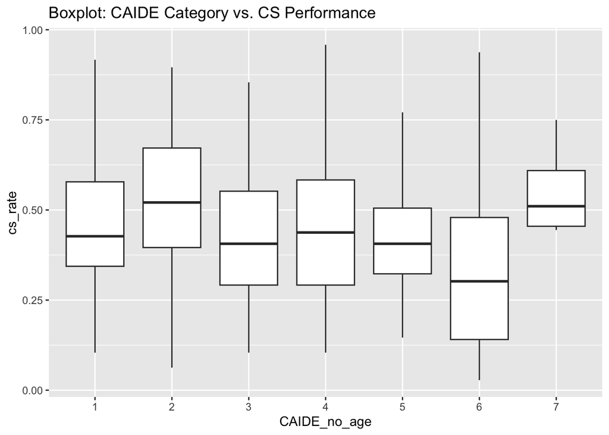

```r
# === 2. CHECK LINEARITY ===
# Since CAIDE_no_age is categorical, use boxplots instead of scatterplots
ggplot(meno_cs_CAIDE_acc, aes(x = CAIDE_no_age, y = cs_rate)) +
  geom_boxplot() + ggtitle("Boxplot: CAIDE Category vs. CS Performance")
```

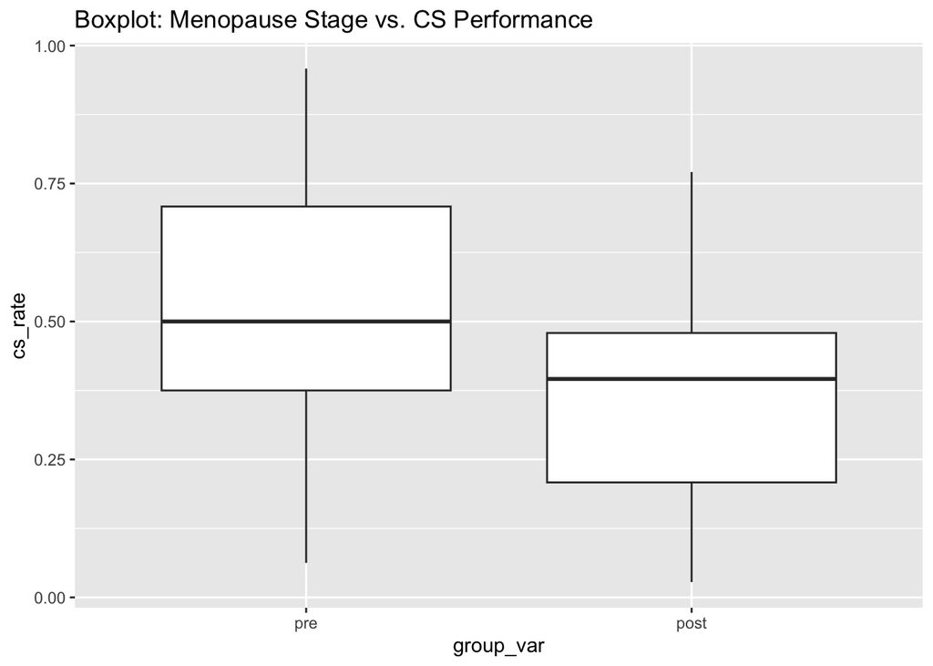

```r
ggplot(meno_cs_CAIDE_acc, aes(x = group_var, y = cs_rate)) +
  geom_boxplot() + ggtitle("Boxplot: Menopause Stage vs. CS Performance")
```

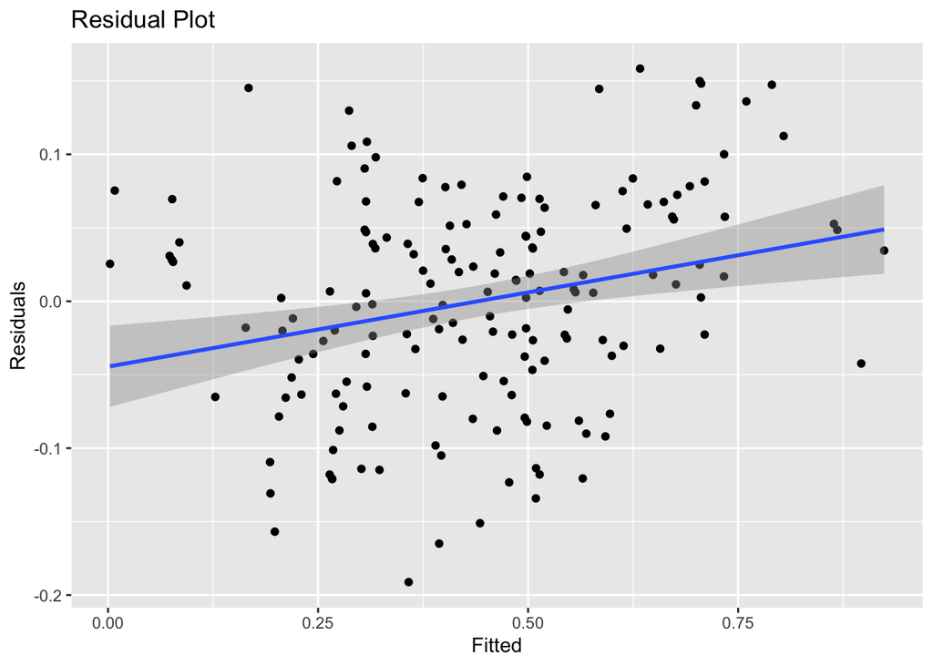

```r
# Residual plot for categorical predictors
fit <- lmer(cs_rate ~ group_var + CAIDE_no_age + task + (1 | id), data = meno_cs_CAIDE_acc, REML = TRUE)
residuals_df <- data.frame(Fitted = fitted(fit), Residuals = resid(fit))

ggplot(residuals_df, aes(x = Fitted, y = Residuals)) +
  geom_point() + geom_smooth(method = "lm") + ggtitle("Residual Plot")
```

```r
# === 3. TEST FOR INTERACTION EFFECT (Menopause Stage * CAIDE) ===
interaction_model <- lmer(cs_rate ~ group_var * CAIDE_no_age + task + (1 | id),
                          data = meno_cs_CAIDE_acc, REML = TRUE)
interaction_summary <- summary(interaction_model)

cat("\n=== TEST FOR INTERACTION ===\n")
```

```
##
## === TEST FOR INTERACTION ===
```

```r
print(interaction_summary)
```

```
## Linear mixed model fit by REML ['lmerMod']
## Formula: cs_rate ~ group_var * CAIDE_no_age + task + (1 | id)
##    Data: meno_cs_CAIDE_acc
##
## REML criterion at convergence: -120.9
##
## Scaled residuals:
##      Min       1Q   Median       3Q      Max
## -1.92009 -0.52590  0.06651  0.51473  1.60802
##
## Random effects:
##  Groups   Name        Variance Std.Dev.
##  id       (Intercept) 0.02141  0.14632
##  Residual             0.00919  0.09586
## Number of obs: 170, groups:  id, 85
##
## Fixed effects:
##                           Estimate Std. Error t value
## (Intercept)               0.413411   0.054586   7.574
## group_var1                0.090495   0.054586   1.658
## CAIDE_no_age2             0.131096   0.100358   1.306
## CAIDE_no_age3             0.041946   0.072171   0.581
## CAIDE_no_age4             0.025527   0.063985   0.399
## CAIDE_no_age5            -0.009115   0.083922  -0.109
## CAIDE_no_age6            -0.030020   0.082292  -0.365
## CAIDE_no_age7             0.230903   0.147208   1.569
## task1                     0.095261   0.007352  12.956
## group_var1:CAIDE_no_age2 -0.087654   0.100358  -0.873
## group_var1:CAIDE_no_age3 -0.035435   0.072171  -0.491
## group_var1:CAIDE_no_age4  0.018930   0.063985   0.296
## group_var1:CAIDE_no_age5 -0.093750   0.083922  -1.117
## group_var1:CAIDE_no_age6  0.010489   0.082292   0.127
```

```
## fit warnings:
## fixed-effect model matrix is rank deficient so dropping 1 column / coefficient
```

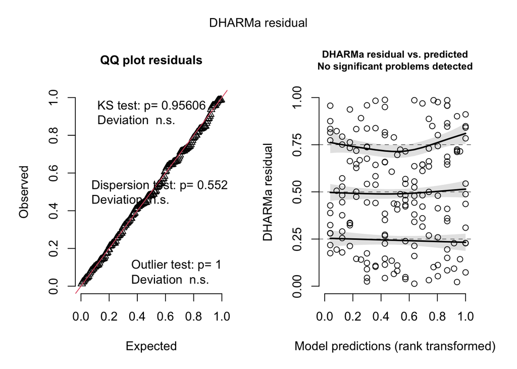

```r
# === 4. CHECK FOR HOMOSCEDASTICITY (Equal Variance of Residuals) ===

library(DHARMa)

# Simulate residuals
sim_res <- simulateResiduals(fittedModel = fit, n = 1000)

# Plot diagnostic residuals
plot(sim_res)
```

## 13 Sup9 (Table S8): Mixed-Effects Models — CAIDE Continuous Predicting CS

### 13.1 Pre-Menopausal Group

```r
cs_acc_CAIDE_pre <- cleaned_data_df %>%
  select(id, group_var, CAIDE, cs_rate_easy, cs_rate_hard) %>%
  filter(group_var == "pre") %>%
  mutate(CAIDE = as.numeric(CAIDE)) %>%
  pivot_longer(!c(id, group_var, CAIDE), names_to = "task", values_to = "cs_rate") %>%
  mutate(task = str_replace_all(task, "cs_rate_", ""),
         task = factor(task, levels = c("easy", "hard")))

contrasts(cs_acc_CAIDE_pre$task) <- contr.sum(2)

lmm_CAIDE_cs_pre <- lmer(cs_rate ~ task + CAIDE + (1 | id), data = cs_acc_CAIDE_pre, REML = TRUE)

anova(lmm_CAIDE_cs_pre, type = "III")
```

|  | npar | Sum Sq | Mean Sq | F value |
| --- | --- | --- | --- | --- |
| task | 1 | 1.107644056 | 1.107644056 | 115.9378043 |
| CAIDE | 1 | 0.007642549 | 0.007642549 | 0.7999504 |

```r
summary(lmm_CAIDE_cs_pre)$coefficients
```

```
##                Estimate Std. Error    t value
## (Intercept)  0.57265893 0.05965121  9.6001223
## task1        0.11483135 0.01066468 10.7674419
## CAIDE       -0.01273625 0.01424001 -0.8943995
```

```r
sjPlot::tab_model(lmm_CAIDE_cs_pre,
  dv.labels = "Pre-Meno:\nTask and CAIDE Risk score predicting CS", p.style = "scientific_stars", df.method = "satterthwaite")
```

Pre-Meno: Task and CAIDE Risk score predicting CS

Predictors

Estimates

CI

p

(Intercept)

0.57 ***

0.45 – 0.69

**6.182e-12**

task1

0.11 ***

0.09 – 0.14

**1.603e-13**

CAIDE

-0.01

-0.04 – 0.02

3.765e-01

Random Effects

σ<sup>2</sup>

0.01

τ<sub>00</sub> <sub>id</sub>

0.03

ICC

0.73

N <sub>id</sub>

42

Observations

84

Marginal R<sup>2</sup> / Conditional R<sup>2</sup>

0.283 / 0.806

- p<0.05 ** p<0.01 *** p<0.001

```r
check_collinearity(lmm_CAIDE_cs_pre)
```

| Term | VIF | VIF_CI_low | VIF_CI_high | SE_factor | Tolerance | Tolerance_CI_low | Tolerance_CI_high |
| --- | --- | --- | --- | --- | --- | --- | --- |
| task | 1 | 1 | NaN | 1 | 1 | NaN | 1 |
| CAIDE | 1 | 1 | NaN | 1 | 1 | NaN | 1 |

```r
check_outliers(lmm_CAIDE_cs_pre)
```

```
## 4 outliers detected: cases 34, 50, 63, 75.
## - Based on the following method and threshold: cook (0.8).
## - For variable: (Whole model).
```

#### 13.1.1 Plot — Pre-Meno

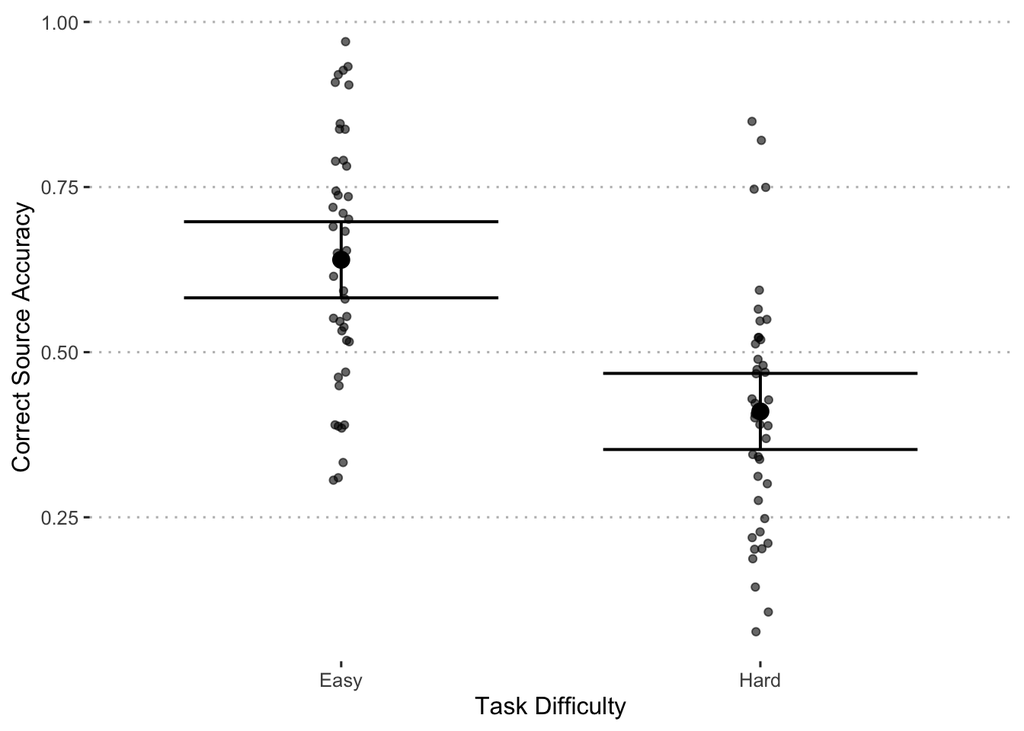

```r
effect_plot(lmm_CAIDE_cs_pre, pred = task, plot.points = TRUE, jitter = 0.02,
            line.thickness = 0.7, x.label = "Task Difficulty", y.label = "Correct Source Accuracy") +
  scale_x_discrete(labels = c("Easy", "Hard")) + theme_pubclean()
```

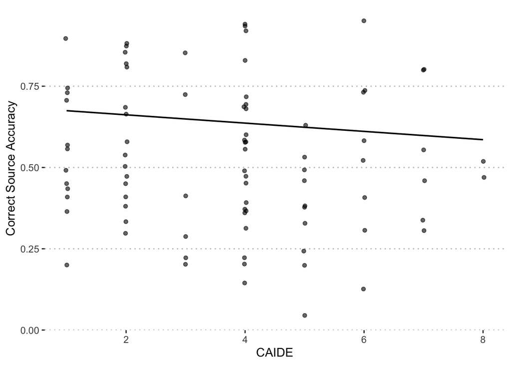

```r
effect_plot(lmm_CAIDE_cs_pre, pred = CAIDE, plot.points = TRUE, jitter = 0.02,
            line.thickness = 0.7, x.label = "CAIDE", y.label = "Correct Source Accuracy") +
  theme_pubclean()
```

### 13.2 Post-Menopausal Group

```r
cs_acc_CAIDE_post <- cleaned_data_df %>%
    select(id, group_var, CAIDE, cs_rate_easy, cs_rate_hard) %>%
    mutate_at("CAIDE", ~as.numeric(.)) %>%
    filter(group_var=="post" & CAIDE <11) %>%
      pivot_longer(!c(id, group_var, CAIDE), names_to = "task", values_to = "cs_rate") %>%
    mutate(task = str_replace_all(task, "cs_rate_", ""),
         task = factor(task, levels = c("easy", "hard")))


contrasts(cs_acc_CAIDE_post$task) <- contr.sum(2)

lmm_CAIDE_cs_post <- lmer(cs_rate ~ task + CAIDE + (1 | id), data = cs_acc_CAIDE_post, REML = TRUE)

anova(lmm_CAIDE_cs_post, type = "III")
```

|  | npar | Sum Sq | Mean Sq | F value |
| --- | --- | --- | --- | --- |
| task | 1 | 0.48171113 | 0.48171113 | 62.494180 |
| CAIDE | 1 | 0.01194091 | 0.01194091 | 1.549139 |

```r
summary(lmm_CAIDE_cs_post)$coefficients
```

```
##                Estimate  Std. Error   t value
## (Intercept)  0.50362553 0.125146620  4.024284
## task1        0.07572751 0.009579303  7.905326
## CAIDE       -0.01846401 0.014834770 -1.244644
```

```r
sjPlot::tab_model(lmm_CAIDE_cs_post,
  dv.labels = "Post-Meno:\nTask and CAIDE Risk score predicting CS", p.style = "scientific_stars", df.method = "satterthwaite")
```

Post-Meno: Task and CAIDE Risk score predicting CS

Predictors

Estimates

CI

p

(Intercept)

0.50 ***

0.25 – 0.76

**2.471e-04**

task1

0.08 ***

0.06 – 0.10

**8.960e-10**

CAIDE

-0.02

-0.05 – 0.01

2.205e-01

Random Effects

σ<sup>2</sup>

0.01

τ<sub>00</sub> <sub>id</sub>

0.02

ICC

0.67

N <sub>id</sub>

42

Observations

84

Marginal R<sup>2</sup> / Conditional R<sup>2</sup>

0.218 / 0.743

- p<0.05 ** p<0.01 *** p<0.001

```r
check_collinearity(lmm_CAIDE_cs_post)
```

| Term | VIF | VIF_CI_low | VIF_CI_high | SE_factor | Tolerance | Tolerance_CI_low | Tolerance_CI_high |
| --- | --- | --- | --- | --- | --- | --- | --- |
| task | 1 | 1 | NaN | 1 | 1 | NaN | 1 |
| CAIDE | 1 | 1 | NaN | 1 | 1 | NaN | 1 |

```r
check_outliers(lmm_CAIDE_cs_post)
```

```
## 2 outliers detected: cases 5, 7.
## - Based on the following method and threshold: cook (0.8).
## - For variable: (Whole model).
```

#### 13.2.1 Plot — Post-Meno

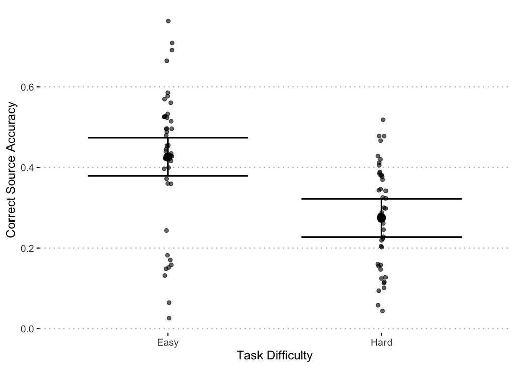

```r
effect_plot(lmm_CAIDE_cs_post, pred = task, plot.points = TRUE, jitter = 0.02,
            line.thickness = 0.7, x.label = "Task Difficulty", y.label = "Correct Source Accuracy") +
  scale_x_discrete(labels = c("Easy", "Hard")) + theme_pubclean()
```

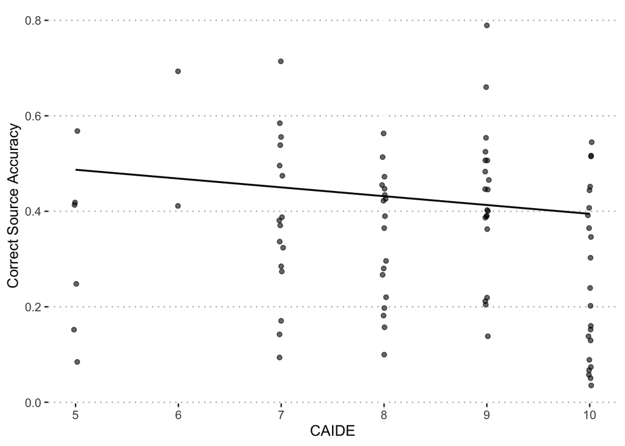

```r
effect_plot(lmm_CAIDE_cs_post, pred = CAIDE, plot.points = TRUE, jitter = 0.02,
            line.thickness = 0.7, x.label = "CAIDE", y.label = "Correct Source Accuracy") +
  theme_pubclean()
```